# Taipei_land_price_analysis

B03501044-Jeffery_Sheih

12/22/2017

### 動機

起因於最近正在找台北的房子，希望短期內能找到一個離學校不遠但價錢尚能接受的住處，而長期而言，也希望畢業後能在台北找到不錯的房子，對於可能影響台北房價的因素必須有一定的了解，如地區性、交通便利性、屋齡、主要建材等等，而在此次的作業中希望能透過單位面積的價位區分出房價會如何座落在台北各區。

### 資料概況

本資料提供建物交易、用途、車位、建物情況等，此次分析主要觀察單價每平方公尺的價格在不同地區的高低，但由於租金總額元大多數資料不全，而由內政部不動產交易查詢服務網推得`租賃總額(元/月)/總坪數(坪) = 單價每平方公尺`

```r
head(taipei_rent)
```

```
##   鄉鎮市區        租賃標的          土地區段位置或建物區門牌
## 1   內湖區            建物   臺北市內湖區內湖路一段301~330號
## 2   內湖區            建物 臺北市內湖區內湖路一段387巷1~30號
## 3   內湖區            建物 臺北市內湖區南京東路六段331~360號
## 4   內湖區            建物         臺北市內湖區洲子街31~60號
## 5   中山區            建物       臺北市中山區植福路301~330號
## 6   松山區 房地(土地+建物)    臺北市松山區南京東路五段1~30號
##   租賃總面積平方公尺 都市土地使用分區 非都市土地使用分區
## 1                0.0               商                 NA
## 2                0.0               住                 NA
## 3                0.0               工                 NA
## 4                0.0               工                 NA
## 5                0.0               商                 NA
## 6               37.9               商                 NA
##   非都市土地使用編定 租賃年月日      租賃筆棟數 租賃層次 總樓層數
```

[output cut: 34 more lines]

### 資料篩選

因分析對象為出租型態為住家使用，因此篩選出以下三種類別：住宅大樓(11層含以上有電梯),公寓(5樓含以下無電梯),套房(1房1廳1衛)

```r
head(taipei_target_rent)
```

```
##   鄉鎮市區        租賃標的          土地區段位置或建物區門牌
## 1   內湖區            建物 臺北市內湖區內湖路一段387巷1~30號
## 2   內湖區            建物 臺北市內湖區南京東路六段331~360號
## 3   松山區 房地(土地+建物)    臺北市松山區南京東路五段1~30號
## 4   信義區            建物   臺北市信義區基隆路二段151~180號
## 5   南港區 房地(土地+建物)       臺北市南港區重陽路451~480號
## 6   信義區            建物          臺北市信義區松勤街1~30號
##   租賃總面積平方公尺 都市土地使用分區 非都市土地使用分區
## 1               0.00               住                 NA
## 2               0.00               工                 NA
## 3              37.90               商                 NA
## 4               0.00               商                 NA
## 5              58.12               商                 NA
## 6               0.00             其他                 NA
##   非都市土地使用編定 租賃年月日      租賃筆棟數 租賃層次 總樓層數
```

[output cut: 34 more lines]

### 房屋位址

個人認為因房地產與土地位址息息相關，適合將結果與地圖結合，因此根據`土地區段位置或建物區門牌`利用google map api得到各地址的經緯度

```r
head(location_from_api)
```

```
##                       lat                     lng           location_type
## 1              25.0822416             121.5703474                 ROOFTOP
## 2              25.0583026             121.5844348      RANGE_INTERPOLATED
## 3 Status:OVER_QUERY_LIMIT Status:OVER_QUERY_LIMIT Status:OVER_QUERY_LIMIT
## 4 Status:OVER_QUERY_LIMIT Status:OVER_QUERY_LIMIT Status:OVER_QUERY_LIMIT
## 5              25.0594639               121.61015                 ROOFTOP
## 6              25.0322281             121.5604846                 ROOFTOP
##                                                                                    address
## 1 No. 1, Alley 3, Lane 387, Section 1, Neihu Road, Neihu District, Taipei City, Taiwan 114
## 2           No. 331, Section 6, Nanjing East Road, Neihu District, Taipei City, Taiwan 114
## 3                                                                  Status:OVER_QUERY_LIMIT
## 4                                                                  Status:OVER_QUERY_LIMIT
## 5                       No. 451, Chongyang Road, Nangang District, Taipei City, Taiwan 115
## 6                           No. 1, Songqin Street, Xinyi District, Taipei City, Taiwan 110
```

### 房屋價格高低定義

將單價每平方公尺價格以每100元為區間，分割結果如下，定義600元以上為較高的房屋價格，600元以下則反之

```r
table(cut(taipei_target_rent$單價每平方公尺,breaks = 100*(1:10)))
```

```
##
##   (100,200]   (200,300]   (300,400]   (400,500]   (500,600]   (600,700]
##          12          53          62          62          38          26
##   (700,800]   (800,900] (900,1e+03]
##          12           2           0
```

### SVM

```r
svm_tune = tune(svm, train.x=dat[,c(1,2)], train.y=label,
     kernel="radial", ranges=list(cost=10^(-1:2), gamma=c(.5,1,2)))
print(svm_tune)
```

```
##
## Parameter tuning of 'svm':
##
## - sampling method: 10-fold cross validation
##
## - best parameters:
##  cost gamma
##   100   0.5
##
## - best performance: 0.1905082
```

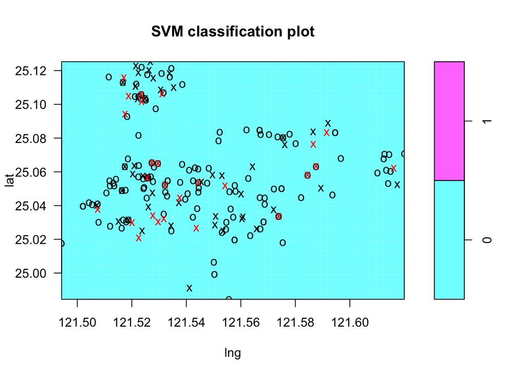

```r
svm_model = svm(label ~ .,data = dat,kernel = "radial",cost = 1,gamma = 1)
plot(svm_model,dat)
```

### 利用地圖顯示房屋價格較高分佈情況

[figure not shown]

```r
#plot the house location on the map
map <- get_map(location = c(lon = 121.564433,lat = 25.037785), zoom = 12,
               language = "zh-TW",maptype = "roadmap")
ggmap(map,darken = c(0.2,"white")) + geom_point(aes(x = lng,y = lat,colour = label),data = dat) +
  labs(x = "Latitude",y = "Longtitude") +
  scale_colour_discrete(name = "House Price",labels = c("Cheap","Expensive"))
```

### 結論

由performance與圖中其實可觀察到svm的表現不佳，推測可能因為影響房地產價格的原因十分眾多，只根據房屋地址推估房地產價格過於粗略，改善方向為考慮其他可能重大影響因素。